# QLSC_Assignment_3.1

Niklas Brake

October 22, 2018

```r
suppressMessages(library(DESeq2))
```

```r
count_matrix = read.table("C:\\Users\\brake\\Documents\\QLSC600\\Module 3\\QLS_counts.tsv");
sample_annotation = read.table("C:\\Users\\brake\\Documents\\QLSC600\\Module 3\\QLS_annotations.tsv");

dds = DESeqDataSetFromMatrix(countData = count_matrix, colData = sample_annotation, design = ~ group)
ddsT <-rlog(dds)
PCs = plotPCA(ddsT, intgroup = "group", ntop = 1000, returnData = TRUE)
PCs
```

```
##           PC1        PC2 group group.1 name
## A1 -23.363647 -15.345094     A       A   A1
## B1   8.169687 -17.097986     B       B   B1
## A2  10.806618   5.912861     A       A   A2
## A3 -17.018750  11.838609     A       A   A3
## B2  12.056107   6.688231     B       B   B2
## A4 -19.376134   8.334029     A       A   A4
## B3  13.227093  -2.077580     B       B   B3
## B4  15.499026   1.746930     B       B   B4
```

One observes that PC1 segregates the data into group A and group B, with the exception of one A sample, who’s PC1 is positive. This is sample A2. If we assume there are two clusters of data corresponding to our two groups, we could use Gaussian mixture models and the posterior probabilies of each sample to determine how well it “groups” with the others.

```r
dds = DESeq(dds)
DE_Results = results(dds)
DE_Results[DE_Results$padj < 0.01 & !is.na(DE_Results$padj),]
```

```
## log2 fold change (MAP): group B vs A
## Wald test p-value: group B vs A
## DataFrame with 373 rows and 6 columns
##          baseMean log2FoldChange     lfcSE      stat       pvalue
##         <numeric>      <numeric> <numeric> <numeric>    <numeric>
## Sgk3    407.49165      0.8372438 0.2173943  3.851269 1.175074e-04
## Cpa6     45.22598      1.6037797 0.3296475  4.865136 1.143784e-06
## Prex2   655.67757      2.3947175 0.3181370  7.527316 5.179381e-14
## Rdh10  1092.63130     -1.3413982 0.2605671 -5.147996 2.632846e-07
## Il1rl1  635.15071     -1.8942450 0.3189523 -5.938960 2.868360e-09
## ...           ...            ...       ...       ...          ...
## Pcgf5    845.0844     -1.2136914 0.2626456 -4.621023 3.818516e-06
## Gsto1   5830.7654     -0.8061702 0.2036140 -3.959307 7.516747e-05
## Gsto2    169.3438     -1.4488935 0.3210616 -4.512821 6.397113e-06
## Add3    3837.7707      0.5792550 0.1332371  4.347550 1.376665e-05
## Dusp5    365.9472     -0.7429779 0.1740234 -4.269414 1.959871e-05
##                padj
##           <numeric>
## Sgk3   5.582008e-03
## Cpa6   2.006168e-04
## Prex2  1.180985e-10
## Rdh10  6.210339e-05
## Il1rl1 1.401501e-06
## ...             ...
## Pcgf5  0.0004427214
## Gsto1  0.0041634256
## Gsto2  0.0006711232
## Add3   0.0012390887
## Dusp5  0.0016055687
```

```r
count_matrix2 = count_matrix[,c(1:2,4:8)]
sample_annotation2 = sample_annotation[c(1:2,4:8),]
dds2 = DESeqDataSetFromMatrix(countData = count_matrix2, colData = sample_annotation2, design = ~ group)

dds2 = DESeq(dds2)
DE_Results2 = results(dds2)
DE_Results2[DE_Results2$padj < 0.01 & !is.na(DE_Results2$padj),]
```

```
## log2 fold change (MAP): group B vs A
## Wald test p-value: group B vs A
## DataFrame with 1585 rows and 6 columns
##           baseMean log2FoldChange      lfcSE      stat       pvalue
##          <numeric>      <numeric>  <numeric> <numeric>    <numeric>
## Sgk3     421.10909      0.8941662  0.2497850  3.579743 3.439324e-04
## Cpa6      49.53204      1.8759462  0.4074570  4.604035 4.143825e-06
## Prex2    731.47316      2.1247903  0.4147767  5.122733 3.011392e-07
## Rdh10   1137.86780     -1.7955958  0.1941614 -9.247953 2.288324e-20
## Defb41    21.12648     -2.2140868  0.4164094 -5.317091 1.054394e-07
## ...            ...            ...        ...       ...          ...
## Nhlrc2   1426.8662      0.2917367 0.08085278  3.608246 3.082747e-04
## Afap1l2   363.5608      1.1401178 0.17697915  6.442102 1.178297e-10
## Ablim1   3087.9009      0.4146745 0.12212500  3.395492 6.850539e-04
## Atrnl1   1276.6648      0.8579542 0.22640695  3.789434 1.509910e-04
## Hspa12a   123.2419     -1.9962492 0.41659620 -4.791808 1.652847e-06
##                 padj
##            <numeric>
## Sgk3    3.697075e-03
## Cpa6    7.828347e-05
## Prex2   7.404733e-06
## Rdh10   3.987977e-18
## Defb41  2.821566e-06
## ...              ...
## Nhlrc2  3.375250e-03
## Afap1l2 5.909287e-09
## Ablim1  6.609703e-03
## Atrnl1  1.837344e-03
## Hspa12a 3.427156e-05
```

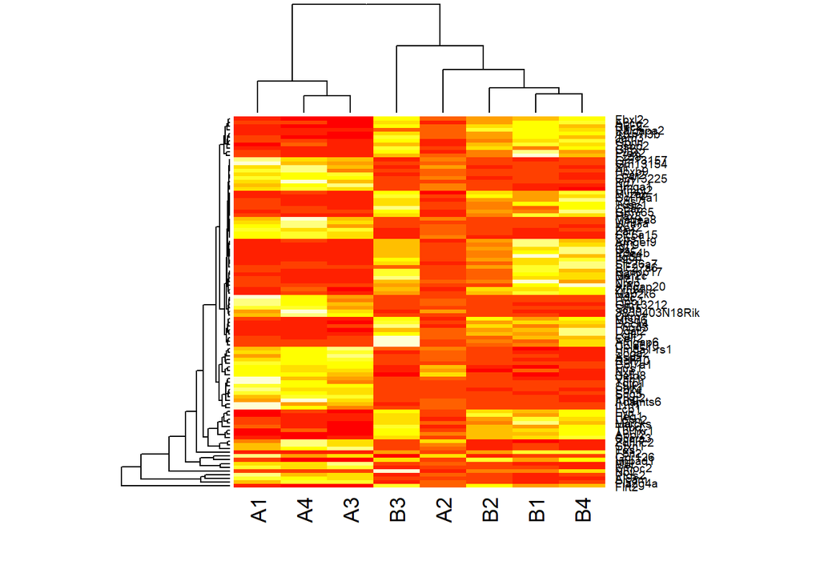

```r
ddsshort = dds[order(DE_Results$padj)[c(1:100)],]
heatmap(counts(ddsshort, normalized = TRUE))
```

This presents clustering similar to what was seen in the PCA. However, since we are choosing genes that we already know identify group A from group B, the result of the clustering algorithm is biased to our selection of data fed to it.

We know that genes with low expression levels tend not the distinguish between groups well. Since this is true regardless of the specific phenotype we are looking at, a less biased sampling would be to select for genes with high expression levels.